# Lesson 106 lab · Temporal link prediction: test the candidates

**Teacher solution** · Real Wikipedia event stream (Tier B). Complete source-candidate scoring replay. Three live implementation tasks; source generation is available below. Start with retrieval and keep the solution closed until you try. No learner mastery is inferred from author execution.

```python
# PROVIDED — standalone runtime; restart the kernel if pip upgrades an imported package.
import sys,subprocess,importlib.metadata
required={'numpy':'2.5.0','scikit-learn':'1.9.0'}
missing=[]
for package,version in required.items():
    try: current=importlib.metadata.version(package)
    except importlib.metadata.PackageNotFoundError: current=None
    if current!=version: missing.append(package+'=='+version)
if missing: subprocess.check_call([sys.executable,'-m','pip','install',*missing])
print('Python',sys.version.split()[0],required)
```

```
Python 3.12.3 {'numpy': '2.5.0', 'scikit-learn': '1.9.0'}
```

From Lesson 105 to this lesson

The representation alone does not define the test. Fix the positive questions and sampled negative candidates before judging a scorer.

**Quick prerequisite reminder**

A positive is an observed interaction. A negative is a comparison under a declared sampling rule. Precision measures how many selected candidates are positive; recall measures how many positives were selected.

One tangible win: explain exactly what a future-edge score measures—and expose when an easy candidate set makes memorization look intelligent. Core lesson: 20–30 minutes. Lab: 40–60 minutes, plus the complete source replay.

**The next problem.** L105 established what a representation retains. Now we must decide what prediction we are evaluating. A model can use legal history and still receive an unconvincing test: distinguish a familiar pair from a randomly constructed pair that almost never interacts. For our relational-learning mission, beating that test alone is weak evidence that a learned relational model adds value.

## 2 · Define the prediction before the model

**An interaction is an occurrence.** An editor can edit the same page repeatedly. Predicting its next edit differs from predicting its first-ever connection to that page. A previously observed pair may be positive again.

**A query specifies a source, destination and time.** A scorer assigns a number s(u,v,t), using permitted history. A positive is an observed interaction. A sampled negative is a comparison pair declared absent under the evaluation's observation interval and sampling rules. It does not mean the pair will never interact.

> **In plain terms.** “Which of these candidate interactions occurred?” is narrower than “which interactions will occur tomorrow?”

The Wikipedia experiment supplies the positive event times and an equal number of negative examples. It tests discrimination at those times. It does not predict when the next event occurs, enumerate every possible edge, or estimate tomorrow's total edits. A deployment forecast needs a horizon, eligible node population, feature availability, observation coverage and treatment of incomplete labels.

**Do not conflate two uses of inductive.** An unseen *edge* is a new pair; both endpoints may be familiar. An unseen *node* is an entity absent from training. The paper's inductive negative sampler concerns pairs first observed after the training/validation period. The released loader also withholds some nodes' early interactions. Those are separate mechanisms. [Primary source: §§3,5](https://arxiv.org/html/2207.10128v2).

## 3 · Model architecture: EdgeBank as a membership test

**EdgeBank has no fitted weights.** Its state is a set of remembered directed pairs. Given Q candidate pairs, it returns Q binary scores: 1 if the pair is in memory, otherwise 0. A score of 1 is a ranking signal, not a calibrated probability.

**Worked example.** Before query time 10, history contains AX@1, AY@3 and BX@8. Candidate AX receives 1; candidate BY receives 0. After an actual BY event is observed, it may enter memory for a later query. Negative candidates never enter memory merely because we scored them.

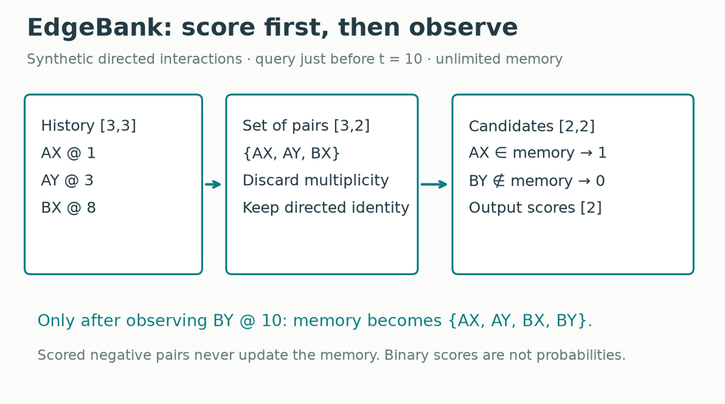

Synthetic membership trace: score AX and BY from strictly earlier history, then update only with observed positives.

**Read the diagram:** trace the inputs to the prediction first, then locate the operation taught in this section. The adjacent text explains the symbols; on a narrow screen, scroll the figure sideways.

**Unlimited memory** retains every supplied historical pair. **Window memory** forgets older events before forming the set. Recency can remove obsolete connections, reducing false positives. It can also forget a genuinely recurring pair, reducing true positives. Neither memory discovers a first-ever edge.

The paper describes a recent fixed-duration window related to test duration. The released `fixed` implementation instead computes the 0.85 quantile of the current history's event times and retains events at or above it. Its duration changes with event density and history growth. Our named replay uses that released operator, with this deviation visible. There is no optimizer, loss, epoch schedule or checkpoint to tune. [Paper §4](https://arxiv.org/html/2207.10128v2#S4) · [pinned implementation](https://github.com/fpour/DGB/blob/7793e9449f5321c7e39b24c0585e3c3de7cf9f5e/EdgeBank/link_pred/edge_bank_baseline.py).

### A quantile window does not expire during idle time

Take ten supplied history events at times **[0,1,2,3,4,5,6,7,7,7]**. One of the time-7 events is A→X; none of the other events use that pair. The 0.85 quantile is **7**, so the released operator keeps all three time-7 events. Ties mean it retains **30% of events**, not exactly 15%.

Score A→X at time 8, then again at time 100 after no new events. The history and quantile are unchanged, so both scores are 1. This operator does not receive the query time; elapsed wall-clock time alone cannot evict the pair.

Now append two unrelated events at times 101 and 102, and query at 103. There are twelve history events. With the released linear quantile convention, the fractional zero-based index is `0.85 × 11 = 9.35`. Positions 9 and 10 contain times 7 and 101, so the boundary becomes `7 + 0.35 × (101−7) = 39.9`. Only the events at 101 and 102 remain; A→X now scores 0.

| Query time | Boundary | A→X score |
| --- | --- | --- |
| 8 | 7 | 1 |
| 100 | 7 | 1 |
| 103 | 39.9 | 0 |

**Work it through.** Compare a different policy that retains history from the last ten time units before the query. Would A→X still score 1 at time 100? Explain which input caused the released operator to forget it at time 103.

**Check the retention rule**

A ten-unit clock window at time 100 excludes the event at 7, so its score is 0. The released quantile operator retains it until the supplied event-time distribution changes. Two other pairs' later events move the quantile and evict A→X. Both are possible memory policies, but they answer different notions of recency; the named replay preserves the released one.

**Trace the clock.** The source evaluates batches of 200 positives using training/validation history plus earlier test batches. It then adds the observed positives for later batches. This delays within-batch updates. Equal timestamps can cross batch boundaries; row order alone cannot establish a strict before-event history. The replay reports such exposure. The lab's `legal_history` exercise implements the stricter clock as a separate contract.

Implement the membership computation in TODO 2 below.

## 4 · Change the negatives; keep the scorer fixed

**Random negatives** draw from the endpoint population. In a sparse interaction graph, many random pairs have never interacted. A memory baseline often gives them 0.

**Historical negatives** preferentially choose pairs observed before the current batch but not active in its time interval. A baseline that remembers every old pair often gives these negatives 1.

**Inductive negatives** further exclude pairs observed during training/validation. They target pairs first seen during test history and absent in the current interval. If too few eligible pairs exist, the source fills the remainder with random pairs. This is not a claim that the endpoints are unseen nodes. [Paper §5](https://arxiv.org/html/2207.10128v2#S5).

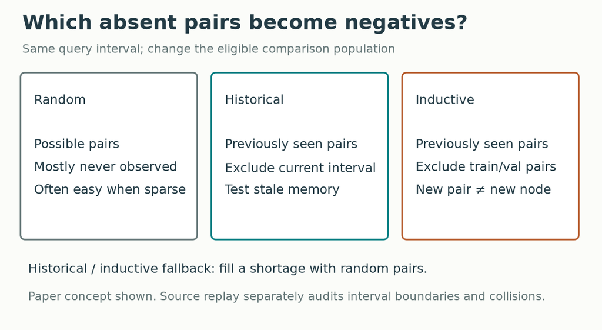

Candidate populations differ even when the scorer and positive events stay fixed. Inductive pairs need not involve unseen nodes.

**Worked example.** Keep two positive scores fixed at [1,0]. With two never-seen negative pairs, their scores are [0,0]. Replace both with remembered-but-currently-absent pairs and their scores become [1,1]. Nothing changed inside the model. Its evaluation becomes harder.

**Predict first:** as the number of remembered negatives rises from zero to two, will the score improve or deteriorate?

**Portable intervention:** remembered negative count 0 / 1 / 2 gives AP 0.7500 / 0.5000 / 0.4167 and AUROC 0.7500 / 0.5000 / 0.2500. Predict these values before calculating.

The widget changes only the synthetic negative set. It is a controlled illustration, not the paper's measured Wikipedia result. A real historical sampler must also respect the observation interval, available history, exclusion set, fallback rule and reproducible random stream.

> **Source audit.** The released random sampler first excludes positive pairs, then its caller replaces each sampled source with the corresponding positive source. That second operation can reintroduce a positive pair. We preserve and count these collisions in the source replay. A corrected accept/reject sampler would be a separate experiment; calling it an exact replay would hide a protocol change.

## 5 · Derive the metrics—including ties

**Precision** is the fraction of predicted positives that are actual positives. **Recall** is the fraction of actual positives retrieved. **Average precision (AP)** sums precision weighted by each increase in recall as the score threshold falls. Equal scores enter together; do not order tied examples arbitrarily.

For binary scores there are only two groups. Let P and N be the positive and negative counts. Let a be the number of positives scoring 1 and b the number of negatives scoring 1. The first group has precision a/(a+b) and recall a/P. The final group includes everything, with precision P/(P+N) and remaining recall 1−a/P:

**AP = (a/P) × a/(a+b) + (1−a/P) × P/(P+N).**

Use zero for the first contribution when a+b=0. Here P=N=2 and a=1. With b=0, AP = ½×1 + ½×½ = **0.75**. With b=2, AP = ½×⅓ + ½×½ = **5/12 ≈ 0.4167**.

**AUROC** is the probability that a uniformly drawn positive outranks a uniformly drawn negative, awarding half credit for a tie. The pairwise formula is:

**AUROC = [a(N−b) + ½{ab + (P−a)(N−b)}] / (PN).**

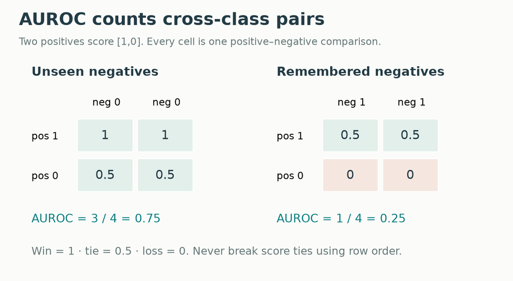

Pairwise AUROC credits: one for a win, half for a tie, zero for a loss. The same two positives face different negatives.

In the example, AUROC falls from **0.75** to **0.25**. The below-chance result is possible because the chosen negatives are more likely to be remembered than the positives. Flipping the predictions after seeing test labels would define a new, test-selected method.

**Aggregation matters.** The source averages AP and AUROC over batches, giving its last partial batch the same weight as a full batch. Computing one metric from all predictions is a different operation. Even a size-weighted batch average generally differs from pooled AP or AUROC, because pooling introduces comparisons across batches. We save both, and compare only the source's batch mean to published targets.

**A balanced test is artificial prevalence.** With P=N, an all-tied scorer has AP 0.5. Changing the negative ratio changes precision and AP; keeping the score distributions fixed leaves the population AUROC interpretation unchanged. Neither number here establishes operational precision across all possible Wikipedia pairs. The released samplers also know the endpoint universe from the full file, so this is a retrospective closed-universe test; an online service must declare which nodes are known at each query. [Metric definitions](https://scikit-learn.org/stable/modules/model_evaluation.html#precision-recall-f-measure-metrics).

## 6 · Full Wikipedia replay: predict, then inspect

**Held fixed:** the complete authenticated file, released split, 200-event batches, two memory operators and source execution order. **Varied:** the three negative samplers and memory choice. **Measured:** batch-mean AP/AUROC, pooled diagnostics, collisions, and source prediction agreement.

**Predict before reading:** which memory is likely to produce more false positives on historical negatives?

All **157,474 raw events** were authenticated. Released history: **104650** events; test: **23621** events; held-out nodes: **922**. Every test event was evaluated in all six conditions, five times.

| Sampler | Memory | Replay AP | Paper AP | Replay AUROC | Paper AUROC | Numeric status |
| --- | --- | --- | --- | --- | --- | --- |
| rnd | unlimited | 0.9045 ± 0.0000 | 0.90 ± 0.000 | 0.9082 ± 0.0000 | 0.91 ± 0.000 | CLOSE |
| rnd | window | 0.8700 ± 0.0000 | 0.87 ± 0.000 | 0.8713 ± 0.0000 | 0.87 ± 0.000 | CLOSE |
| hist_nre | unlimited | 0.4969 ± 0.0008 | 0.50 ± 0.000 | 0.4924 ± 0.0016 | 0.49 ± 0.001 | CLOSE |
| hist_nre | window | 0.7111 ± 0.0021 | 0.71 ± 0.001 | 0.7688 ± 0.0017 | 0.77 ± 0.001 | CLOSE |
| induc_nre | unlimited | 0.4757 ± 0.0001 | 0.48 ± 0.000 | 0.4334 ± 0.0001 | 0.43 ± 0.000 | CLOSE |
| induc_nre | window | 0.4645 ± 0.0002 | 0.46 ± 0.000 | 0.4043 ± 0.0004 | 0.40 ± 0.001 | CLOSE |

Values are mean ± population SD for our replay, alongside the paper’s reported SD. CLOSE compares means only; reported variability need not match. Every batch prediction matched the pinned original memory implementation; an independent metrics library agreed with the visible tie formulas.

- **rnd:** 1 distinct candidate arrays across five iterations; positive/negative collisions per iteration: [27, 27, 27, 27, 27].
- **hist_nre:** 5 distinct candidate arrays across five iterations; positive/negative collisions per iteration: [0, 0, 0, 0, 0].
- **induc_nre:** 5 distinct candidate arrays across five iterations; positive/negative collisions per iteration: [0, 0, 0, 0, 0].

**Aggregation witness:** inductive/window pooled AP is 0.4572, versus batch-mean AP 0.4645, from exactly the same predictions. Only the latter is the source's paper-comparison metric.

Rows in history at or after a batch's first timestamp, summed across batch starts: **5** per iteration. This audit count is not a claim about feature ingestion times, which are unavailable.

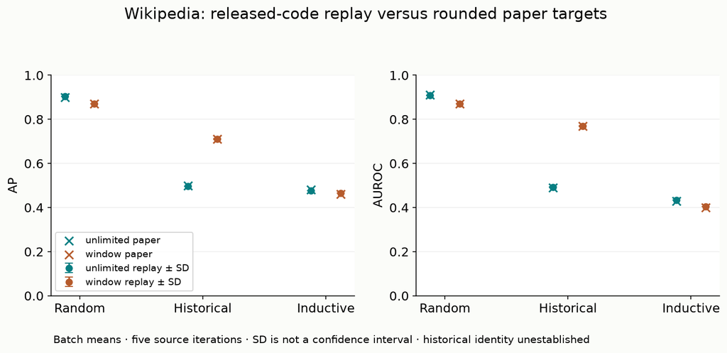

Measured full Wikipedia source replay. Points are means with population SD over five source iterations; crosses are rounded paper targets. Zero SD can mean an identical candidate stream, not certainty.

**How to interpret variability.** The original random sampler resets an instance RNG to seed 2 each run. Historical/inductive methods draw from global NumPy state, which their reset method does not reset. Five loop iterations therefore do not mean five independent training seeds. We retain those semantics and report distinct candidate arrays. Zero variability on a repeated stream is not a confidence interval.

> **Scope check.** This is the complete declared Wikipedia source replay for six conditions and five iterations. Numerical CLOSE means both metrics fall within the predeclared 0.015 absolute tolerance of rounded paper targets. FAIL means they do not. Prediction parity with released code does not establish historical experiment identity. Other datasets and neural baselines are NOT_RUN. See the [protocol and exact commands](https://avistian.github.io/relational/labs/l106-reproduction.md).

## 7 · Lab: implement, test, defend

Open the [student notebook](https://avistian.github.io/relational/labs/0106-temporal-link-prediction.ipynb), or inspect the [executed solution](https://avistian.github.io/relational/labs/html/0106-temporal-link-prediction.html) after attempting it. The notebook explains the mechanism, embeds portable figures and exposes the implementation. No hidden `relkit` import is needed.

1. **TODO:** implement the strict event/availability gate; test ties and late arrival.
2. **TODO:** implement memory membership with both retention rules; test directed identity and forgetting.
3. **TODO:** implement binary-score AP/AUROC with tie handling; compare with a separate metrics implementation.
4. **RUN:** recompute all scores for the full frozen source candidate corpus. Candidate artifacts are authenticated. An explicit source-generation cell permits a fresh full resampling replay; it is slower because the original sampler materializes millions of pairs.

**EXIT:** submit your three functions, all six measured rows, and a 150–250 word defense. Explain whether the evidence supports “this model forecasts future interactions”; identify the candidate distribution, query clock, batch aggregation and one source/prose discrepancy. Propose one new deployment test without selecting its design from test performance.

**Write the EXIT defense before opening the model answer.**

**Next:** L107 examines snapshot methods. Carry the same prediction contract into discrete time: define the forecast interval before constructing labels or releasing a completed snapshot. Ask the teaching agent follow-up questions and paste your EXIT evidence for feedback. Prepared materials remain **PENDING_WRITTEN_DEFENSE** until you demonstrate the skill.

## Reference and primary reading

Read Poursafaei et al., [*Towards Better Evaluation for Dynamic Link Prediction*, §§4–6 and Appendix B](https://arxiv.org/html/2207.10128v2). Inspect the [publication-era code](https://github.com/fpour/DGB/tree/7793e9449f5321c7e39b24c0585e3c3de7cf9f5e/EdgeBank/link_pred) alongside the prose. Keep the [evaluation reference card](https://avistian.github.io/relational/reference/temporal-link-evaluation.html) beside your experiments.

**Carry this forward.** Choose which state a model carries between completed snapshots. [Continue to Lesson 107](https://avistian.github.io/relational/lessons/0107-snapshot-methods.html).

## Implement the live computation

PROVIDED cells handle data and replay. TODO cells define functions used by the complete experiment. CHECK cells test behavior immediately. Predict their outputs before running.

### Imports

```python
from pathlib import Path
import hashlib, urllib.request, random
import numpy as np
DATA_URL='https://snap.stanford.edu/jodie/wikipedia.csv'
DATA_SHA='a6b73e09c0d1e5b9db11e7e7aa416f2e87838a745273e0446a79952cf4cfae09'
```

### TODO 1: before-event history

**Goal and why:** Return a boolean mask for history available strictly before the event query. Validate finite aligned clocks and availability ≥ event time. Why is equality permitted for one clock but not the other?

```python
def legal_history(times, availability, query):
    """Strict event clock; inclusive availability clock. Teaching contract."""
    t,a=np.asarray(times),np.asarray(availability)
    if t.ndim!=1 or a.shape!=t.shape or not np.isfinite(t).all() or not np.isfinite(a).all() or np.any(a<t) or not np.isfinite(query):
        raise ValueError('Aligned finite clocks, availability >= event time required')
    return (t<query)&(a<=query)
```

### CHECK · legal_history

```python
np.testing.assert_array_equal(legal_history([1,2,3,3],[1,4,3,3],3),[True,False,False,False])
try: legal_history([2],[1],3)
except ValueError: pass
else: raise AssertionError('Reject availability before event time')
print('PASS: strict timestamp ties and late arrival')
```

```
PASS: strict timestamp ties and late arrival
```

### TODO 2: memory membership

**Goal and why:** Accept history [N,3], candidates [Q,2], and unlimited/window mode. Apply the released quantile retention rule, then return binary membership scores. Preserve direction; repeated events should not create multiple votes.

```python
def memory_scores(history, candidates, mode='unlimited'):
    """history [N,3]=(source,destination,time); candidates [Q,2]; scores [Q].

    window matches released fixed mode: latest 15% quantile of supplied
    HISTORY EVENTS, not 15% of wall-clock time or a fixed-duration window.
    Caller establishes which history is legal. No current candidates inserted.
    """
    h,c=np.asarray(history),np.asarray(candidates)
    if mode not in ('unlimited','window'):raise ValueError('Unknown memory mode')
    if h.ndim!=2 or h.shape[1]!=3 or c.ndim!=2 or c.shape[1]!=2:raise ValueError('Expected [N,3] and [Q,2]')
    if not np.isfinite(h).all() or not np.isfinite(c).all():raise ValueError('Finite inputs required')
    if len(h) and mode=='window':h=h[h[:,2]>=np.quantile(h[:,2],.85)]
    memory=set(map(tuple,h[:,:2]))
    return np.array([tuple(pair) in memory for pair in c],dtype=np.int8)
```

### CHECK · memory_scores

```python
h=np.array([[1,10,1],[2,11,2],[1,10,3],[3,12,10]],float)
c=np.array([[1,10],[10,1],[2,11],[3,12],[4,13]])
np.testing.assert_array_equal(memory_scores(h,c),[1,0,1,1,0])
np.testing.assert_array_equal(memory_scores(h,c,'window'),[0,0,0,1,0])
np.testing.assert_array_equal(memory_scores(np.empty((0,3)),c),np.zeros(5))
print('PASS: directed identity, repetition, quantile window, empty memory')
```

```
PASS: directed identity, repetition, quantile window, empty memory
```

### TODO 3: binary-score metrics with ties

**Goal and why:** Return [AP, AUROC] for two nonempty binary score vectors. Group equal scores; validate inputs. Derive your answer from counts rather than calling sklearn in this function.

```python
def binary_metrics(positive, negative):
    """AP and AUROC for {0,1} scores, grouping ties at one threshold."""
    p,n=np.asarray(positive),np.asarray(negative)
    if p.ndim!=1 or n.ndim!=1 or not len(p) or not len(n) or not np.isin(np.r_[p,n],[0,1]).all():raise ValueError('Nonempty binary score vectors required')
    tp,fp=float(p.sum()),float(n.sum());P,N=len(p),len(n)
    high_precision=tp/(tp+fp) if tp+fp else 0.
    ap=(tp/P)*high_precision+(1-tp/P)*P/(P+N)
    auc=(tp*(N-fp)+.5*(tp*fp+(P-tp)*(N-fp)))/(P*N)
    return np.array([ap,auc])
```

### CHECK · binary_metrics

```python
from sklearn.metrics import average_precision_score,roc_auc_score
assert np.allclose(binary_metrics([1,0],[0,0]),[.75,.75])
assert np.allclose(binary_metrics([1,0],[1,1]),[5/12,.25])
rng=np.random.default_rng(106)
for _ in range(100):
    p=rng.integers(0,2,rng.integers(1,30));n=rng.integers(0,2,rng.integers(1,30))
    y=np.r_[np.ones(len(p)),np.zeros(len(n))];s=np.r_[p,n]
    assert np.allclose(binary_metrics(p,n),[average_precision_score(y,s),roc_auc_score(y,s)])
print('PASS: tie arithmetic and 100 independent metric comparisons')
```

```
PASS: tie arithmetic and 100 independent metric comparisons
```

### PROVIDED: authenticate and project the complete raw file

```python
def load_events(path):
    path=Path(path)
    if not path.exists():
        path.parent.mkdir(parents=True,exist_ok=True)
        tmp=path.with_suffix('.download');urllib.request.urlretrieve(DATA_URL,tmp);tmp.replace(path)
    digest=hashlib.file_digest(path.open('rb'),'sha256').hexdigest()
    if digest!=DATA_SHA:raise ValueError('Raw data hash mismatch')
    rows=[]
    with path.open() as f:
        next(f)
        for line in f:
            u,v,t,*_=line.split(',',3);rows.append((int(u)+1,int(v)+8228,float(t)))
    events=np.asarray(rows,dtype=np.float64)
    if events.shape!=(157474,3) or np.any(np.diff(events[:,2])<0):raise ValueError('Unexpected event population')
    return events
```

### PROVIDED: released split, explicit Python compatibility adaptation

```python
def released_split(events):
    u,v,t=events.T;val_time,test_time=np.quantile(t,[.70,.85])
    nodes=set(u.astype(np.int64))|set(v.astype(np.int64))
    test_nodes=set(u[t>val_time].astype(np.int64))|set(v[t>val_time].astype(np.int64))
    # Python 3.9 random.sample(set) internally converted the set to tuple.
    held=set(random.Random(2020).sample(tuple(test_nodes),int(.1*len(nodes))))
    observed=np.array([a not in held and b not in held for a,b in zip(u,v)])
    train=(t<=val_time)&observed;valid=(t>val_time)&(t<=test_time);test=t>test_time
    return np.flatnonzero(train|valid),np.flatnonzero(test),sorted(map(int,held)),[float(val_time),float(test_time)]
```

### PROVIDED: complete replay on frozen original candidate arrays

```python
def replay(events,history_ids,test_ids,negative_edges,batch_size=200):
    """Score before adding each batch; arithmetic-mean batch AP/AUC like source.

    negative_edges: [runs, test events, 2]. Also return pooled diagnostics,
    collisions and tie exposure counts; never confuse them with paper metrics.
    """
    runs=[];predictions=[]
    for neg in negative_edges:
        per_mode={k:[] for k in ('unlimited','window')};pred={k:[] for k in per_mode}
        collisions=ties=0
        for start in range(0,len(test_ids),batch_size):
            ids=test_ids[start:start+batch_size];h=events[np.r_[history_ids,test_ids[:start]]];pos=events[ids,:2];n=neg[start:start+len(ids)]
            collisions+=sum(tuple(x) in set(map(tuple,pos)) for x in n)
            ties+=int(np.sum(h[:,2]>=events[ids[0],2]))
            for mode in per_mode:
                scores=memory_scores(h,np.r_[pos,n],mode);p,q=np.split(scores,2)
                per_mode[mode].append(binary_metrics(p,q));pred[mode].append(np.stack([p,q],axis=1))
        r={}
        for mode in per_mode:
            pp=np.concatenate(pred[mode]);r[mode]={'batch_mean':np.mean(per_mode[mode],axis=0).tolist(),'pooled':binary_metrics(pp[:,0],pp[:,1]).tolist(),'batch_metrics':np.asarray(per_mode[mode]).tolist()}
        r.update(collisions=collisions,nonpast_history_records_at_batch_starts=ties)
        runs.append(r);predictions.append(pred)
    return runs,predictions
```

## Authenticate inputs

First raw download is about 560 MB. Existing bytes are always hashed. Embedded candidate artifacts contain all five runs and all test edges; they are original-sampler evidence, not predictions. Default notebook execution recomputes predictions and metrics from scratch. It does not claim fresh candidate generation.

```python
# PROVIDED — candidate bytes are embedded, not computed by a hidden model.
# Their hashes tie this scoring replay to the recorded original-sampler execution.
import base64,io,json
FROZEN={'negatives-hist_nre.npz': {'sha256': '0dd35327882624c1d2f827a4d571c68d1e0cfd548c60999ab6ee391dcc89d4b7', 'base64': 'UEsDBC0AAAAIAAAAIQBLGFDl//////////8JABQAZWRnZXMubnB5AQAQABDW…=='}, 'negatives-induc_nre.npz': {'sha256': '3ddda3e35d377967a69ad16f9938e0ef7718959fe49371cada1f28ed40dbd443', 'base64': 'UEsDBC0AAAAIAAAAIQBYEZCe//////////8JABQAZWRnZXMubnB5AQAQABDW…'}, 'negatives-rnd.npz': {'sha256': 'f262f233a78cc4e0f6db2f0bbe51655504ba0fa0d9bbad9c0d85901dd3d62076', 'base64': 'UEsDBC0AAAAIAAAAIQDu+hLX//////////8JABQAZWRnZXMubnB5AQAQABDW…='}, 'split.npz': {'sha256': '5c02978ff07f2546afa37d76b63c8e54acdb4f98e04c65530fd2e73d19a753be', 'base64': 'UEsDBC0AAAAIAAAAIQBe/YMG//////////8PABQAaGlzdG9yeV9pZHMubnB5…='}}
frozen={}
for name,item in FROZEN.items():
    data=base64.b64decode(item['base64'])
    assert hashlib.sha256(data).hexdigest()==item['sha256'], 'Candidate artifact changed'
    frozen[name]=np.load(io.BytesIO(data),allow_pickle=False)
RAW_PATH=Path('l106-data/wikipedia.csv')
events=load_events(RAW_PATH)
history_ids,test_ids,held_nodes,cuts=released_split(events)
np.testing.assert_array_equal(history_ids,frozen['split.npz']['history_ids'])
np.testing.assert_array_equal(test_ids,frozen['split.npz']['test_ids'])
np.testing.assert_array_equal(held_nodes,frozen['split.npz']['held_nodes'])
print('PASS: authenticated raw data and complete split; no processed data cache')
```

```
PASS: authenticated raw data and complete split; no processed data cache
```

## Original sampler implementation · MIT licensed

The following complete released sampler is retained visibly for auditing and optional regeneration. Source: DGB commit 7793e9449f5321c7e39b24c0585e3c3de7cf9f5e. Pay attention to global versus instance random state and pair-set ordering.

```
MIT License

Copyright (c) 2022 fps

Permission is hereby granted, free of charge, to any person obtaining a copy
of this software and associated documentation files (the "Software"), to deal
in the Software without restriction, including without limitation the rights
to use, copy, modify, merge, publish, distribute, sublicense, and/or sell
copies of the Software, and to permit persons to whom the Software is
furnished to do so, subject to the following conditions:

The above copyright notice and this permission notice shall be included in all
copies or substantial portions of the Software.

THE SOFTWARE IS PROVIDED "AS IS", WITHOUT WARRANTY OF ANY KIND, EXPRESS OR
IMPLIED, INCLUDING BUT NOT LIMITED TO THE WARRANTIES OF MERCHANTABILITY,
FITNESS FOR A PARTICULAR PURPOSE AND NONINFRINGEMENT. IN NO EVENT SHALL THE
AUTHORS OR COPYRIGHT HOLDERS BE LIABLE FOR ANY CLAIM, DAMAGES OR OTHER
LIABILITY, WHETHER IN AN ACTION OF CONTRACT, TORT OR OTHERWISE, ARISING FROM,
OUT OF OR IN CONNECTION WITH THE SOFTWARE OR THE USE OR OTHER DEALINGS IN THE
SOFTWARE.
```

```python
"""
Negative edge sampler
"""

import numpy as np


class RandEdgeSampler_original(object):
    """
    from TGN code
    """

    def __init__(self, src_list, dst_list, seed=None):
        self.seed = None
        self.neg_sample = 'rnd'  # negative edge sampling method: random edges
        self.src_list = np.unique(src_list)
        self.dst_list = np.unique(dst_list)

        if seed is not None:
            self.seed = seed
            self.random_state = np.random.RandomState(self.seed)

    def sample(self, size):
        if self.seed is None:
            src_index = np.random.randint(0, len(self.src_list), size)
            dst_index = np.random.randint(0, len(self.dst_list), size)
        else:
            src_index = self.random_state.randint(0, len(self.src_list), size)
            dst_index = self.random_state.randint(0, len(self.dst_list), size)
        return self.src_list[src_index], self.dst_list[dst_index]

    def reset_random_state(self):
        self.random_state = np.random.RandomState(self.seed)


class RandEdgeSampler(object):

    def __init__(self, src_list, dst_list, seed=None):
        self.seed = None
        self.neg_sample = 'rnd'  # negative edge sampling method: random edges
        self.src_list = np.unique(src_list)
        self.dst_list = np.unique(dst_list)
        self.possible_edges = set([(src, dst) for src in np.unique(src_list) for dst in np.unique(dst_list)])

        if seed is not None:
            self.seed = seed
            self.random_state = np.random.RandomState(self.seed)

    def sample(self, size, pos_src, pos_dst):
        current_pos_e = set([(pos_src[i], pos_dst[i]) for i in range(len(pos_src))])
        current_not_pos_e = list(self.possible_edges - current_pos_e)
        if self.seed is None:
            e_index = np.random.randint(0, len(current_not_pos_e), size)
        else:
            e_index = self.random_state.randint(0, len(current_not_pos_e), size)
        return [current_not_pos_e[idx][0] for idx in e_index], [current_not_pos_e[idx][1] for idx in e_index]

    def reset_random_state(self):
        self.random_state = np.random.RandomState(self.seed)


class RandEdgeSampler_adversarial_original(object):
    """
    Adversarial Random Edge Sampling as Negative Edges
    """

    def __init__(self, src_list, dst_list, ts_list, last_ts_train_val, NEG_SAMPLE, seed=None, rnd_sample_ratio=0):
        """
        'src_list', 'dst_list', 'ts_list' are related to the full data! All possible edges in train, validation, test
        """
        if not (NEG_SAMPLE == 'hist_nre' or NEG_SAMPLE == 'induc_nre'):
            raise ValueError("Undefined Negative Edge Sampling Strategy!")

        self.seed = None
        self.neg_sample = NEG_SAMPLE
        self.rnd_sample_ratio = rnd_sample_ratio
        self.src_list = src_list
        self.dst_list = dst_list
        self.ts_list = ts_list
        self.src_list_distinct = np.unique(src_list)
        self.dst_list_distinct = np.unique(dst_list)
        self.ts_list_distinct = np.unique(ts_list)
        self.ts_init = min(self.ts_list_distinct)
        self.ts_end = max(self.ts_list_distinct)
        self.ts_test_split = last_ts_train_val
        self.e_train_val_l = self.get_edges_in_time_interval(self.ts_init, self.ts_test_split)

        if seed is not None:
            self.seed = seed
            np.random.seed(self.seed)
            self.random_state = np.random.RandomState(self.seed)

    def get_edges_in_time_interval(self, start_ts, end_ts):
        """
        return edges of a specific time interval
        """
        valid_ts_interval = (self.ts_list >= start_ts) * (self.ts_list <= end_ts)
        interval_src_l = self.src_list[valid_ts_interval]
        interval_dst_l = self.dst_list[valid_ts_interval]
        interval_edges = {}
        for src, dst in zip(interval_src_l, interval_dst_l):
            if (src, dst) not in interval_edges:
                interval_edges[(src, dst)] = 1
        return interval_edges

    def get_difference_edge_list(self, first_e_set, second_e_set):
        """
        return edges in the first_e_set that are not in the second_e_set
        """
        difference_e_set = set(first_e_set) - set(second_e_set)
        src_l, dst_l = [], []
        for e in difference_e_set:
            src_l.append(e[0])
            dst_l.append(e[1])
        return np.array(src_l), np.array(dst_l)

    def sample(self, size, current_split_start_ts, current_split_end_ts):
        if self.neg_sample == 'hist_nre':
            negative_src_l, negative_dst_l = self.sample_hist_NRE(size, current_split_start_ts, current_split_end_ts)
        elif self.neg_sample == 'induc_nre':
            negative_src_l, negative_dst_l = self.sample_induc_NRE(size, current_split_start_ts, current_split_end_ts)
        else:
            raise ValueError("Undefined Negative Edge Sampling Strategy!")
        return negative_src_l, negative_dst_l

    def sample_hist_NRE(self, size, current_split_start_ts, current_split_end_ts):
        """
        method one:
        "historical adversarial sampling": (~ historical non repeating edges)
        randomly samples among previously seen edges that are not repeating in current batch,
        fill in any remaining with randomly sampled
        """
        history_e_dict = self.get_edges_in_time_interval(self.ts_init, current_split_start_ts)
        current_split_e_dict = self.get_edges_in_time_interval(current_split_start_ts, current_split_end_ts)
        non_repeating_e_src_l, non_repeating_e_dst_l = self.get_difference_edge_list(history_e_dict,
                                                                                     current_split_e_dict)
        num_smp_rnd = int(self.rnd_sample_ratio * size)
        num_smp_from_hist = size - num_smp_rnd
        if num_smp_from_hist > len(non_repeating_e_src_l):
            num_smp_from_hist = len(non_repeating_e_src_l)
            num_smp_rnd = size - num_smp_from_hist

        replace = len(self.src_list_distinct) < num_smp_rnd
        rnd_src_index = np.random.choice(len(self.src_list_distinct), size=num_smp_rnd, replace=replace)
```

```python
        replace = len(self.dst_list_distinct) < num_smp_rnd
        rnd_dst_index = np.random.choice(len(self.dst_list_distinct), size=num_smp_rnd, replace=replace)

        replace = len(non_repeating_e_src_l) < num_smp_from_hist
        nre_e_index = np.random.choice(len(non_repeating_e_src_l), size=num_smp_from_hist, replace=replace)

        negative_src_l = np.concatenate([self.src_list_distinct[rnd_src_index], non_repeating_e_src_l[nre_e_index]])
        negative_dst_l = np.concatenate([self.dst_list_distinct[rnd_dst_index], non_repeating_e_dst_l[nre_e_index]])

        return negative_src_l, negative_dst_l

    def sample_induc_NRE(self, size, current_split_start_ts, current_split_end_ts):
        """
        method two:
        "inductive adversarial sampling": (~ inductive non repeating edges)
        considers only edges that have been seen (in red region),
        fill in any remaining with randomly sampled
        """
        history_e_dict = self.get_edges_in_time_interval(self.ts_init, current_split_start_ts)
        current_split_e_dict = self.get_edges_in_time_interval(current_split_start_ts, current_split_end_ts)
        induc_adversarial_e = set(set(history_e_dict) - set(self.e_train_val_l)) - set(current_split_e_dict)
        induc_adv_src_l, induc_adv_dst_l = [], []
        if len(induc_adversarial_e) > 0:
            for e in induc_adversarial_e:
                induc_adv_src_l.append(e[0])
                induc_adv_dst_l.append(e[1])
            induc_adv_src_l = np.array(induc_adv_src_l)
            induc_adv_dst_l = np.array(induc_adv_dst_l)

        num_smp_rnd = size - len(induc_adversarial_e)

        if num_smp_rnd > 0:
            replace = len(self.src_list_distinct) < num_smp_rnd
            rnd_src_index = np.random.choice(len(self.src_list_distinct), size=num_smp_rnd, replace=replace)
            replace = len(self.dst_list_distinct) < num_smp_rnd
            rnd_dst_index = np.random.choice(len(self.dst_list_distinct), size=num_smp_rnd, replace=replace)

            negative_src_l = np.concatenate([self.src_list_distinct[rnd_src_index], induc_adv_src_l])
            negative_dst_l = np.concatenate([self.dst_list_distinct[rnd_dst_index], induc_adv_dst_l])
        else:
            rnd_induc_hist_index = np.random.choice(len(induc_adversarial_e), size=size, replace=False)
            negative_src_l = induc_adv_src_l[rnd_induc_hist_index]
            negative_dst_l = induc_adv_dst_l[rnd_induc_hist_index]

        return negative_src_l, negative_dst_l

    def reset_random_state(self):
        self.random_state = np.random.RandomState(self.seed)


class RandEdgeSampler_adversarial(object):
    """
    Adversarial Random Edge Sampling as Negative Edges
    """

    def __init__(self, src_list, dst_list, ts_list, last_ts_train_val, NEG_SAMPLE, seed=None, rnd_sample_ratio=0):
        """
        'src_list', 'dst_list', 'ts_list' are related to the full data! All possible edges in train, validation, test
        """
        if not (NEG_SAMPLE == 'hist_nre' or NEG_SAMPLE == 'induc_nre'):
            raise ValueError("Undefined Negative Edge Sampling Strategy!")

        self.seed = None
        self.neg_sample = NEG_SAMPLE
        self.rnd_sample_ratio = rnd_sample_ratio
        self.src_list = src_list
        self.dst_list = dst_list
        self.ts_list = ts_list
        self.src_list_distinct = np.unique(src_list)
        self.dst_list_distinct = np.unique(dst_list)
        self.ts_list_distinct = np.unique(ts_list)
        self.ts_init = min(self.ts_list_distinct)
        self.ts_end = max(self.ts_list_distinct)
        self.ts_test_split = last_ts_train_val
        self.e_train_val_l = self.get_edges_in_time_interval(self.ts_init, self.ts_test_split)
        self.possible_edges = set([(src, dst) for src in np.unique(src_list) for dst in np.unique(dst_list)])

        if seed is not None:
            self.seed = seed
            np.random.seed(self.seed)
            self.random_state = np.random.RandomState(self.seed)

    def get_edges_in_time_interval(self, start_ts, end_ts):
        """
        return edges of a specific time interval
        """
        valid_ts_interval = (self.ts_list >= start_ts) * (self.ts_list <= end_ts)
        interval_src_l = self.src_list[valid_ts_interval]
        interval_dst_l = self.dst_list[valid_ts_interval]
        interval_edges = {}
        for src, dst in zip(interval_src_l, interval_dst_l):
            if (src, dst) not in interval_edges:
                interval_edges[(src, dst)] = 1
        return interval_edges

    def get_difference_edge_list(self, first_e_set, second_e_set):
        """
        return edges in the first_e_set that are not in the second_e_set
        """
        difference_e_set = set(first_e_set) - set(second_e_set)
        src_l, dst_l = [], []
        for e in difference_e_set:
            src_l.append(e[0])
            dst_l.append(e[1])
        return np.array(src_l), np.array(dst_l)

    def sample(self, size, pos_src, pos_dst, current_split_start_ts, current_split_end_ts):
        if self.neg_sample == 'hist_nre':
            negative_src_l, negative_dst_l = self.sample_hist_NRE(size, pos_src, pos_dst, current_split_start_ts,
                                                                  current_split_end_ts)
        elif self.neg_sample == 'induc_nre':
            negative_src_l, negative_dst_l = self.sample_induc_NRE(size, pos_src, pos_dst, current_split_start_ts,
                                                                   current_split_end_ts)
        else:
            raise ValueError("Undefined Negative Edge Sampling Strategy!")
        return negative_src_l, negative_dst_l

    def sample_random_not_positive_e(self, num_smp_rnd, pos_src, pos_dst):
        current_pos_e = set([(pos_src[i], pos_dst[i]) for i in range(len(pos_src))])
        current_not_pos_e = list(self.possible_edges - current_pos_e)
        replace = len(self.dst_list_distinct) < num_smp_rnd
        e_index = np.random.choice(len(current_not_pos_e), size=num_smp_rnd, replace=replace)
        neg_e_src = np.array([current_not_pos_e[idx][0] for idx in e_index])
        neg_e_dst = np.array([current_not_pos_e[idx][1] for idx in e_index])
        return neg_e_src, neg_e_dst
```

```python
    def sample_hist_NRE(self, size, pos_src, pos_dst, current_split_start_ts, current_split_end_ts):
        """
        method one:
        "historical adversarial sampling": (~ historical non repeating edges)
        randomly samples among previously seen edges that are not repeating in current batch,
        fill in any remaining with randomly sampled
        """
        history_e_dict = self.get_edges_in_time_interval(self.ts_init, current_split_start_ts)
        current_split_e_dict = self.get_edges_in_time_interval(current_split_start_ts, current_split_end_ts)
        non_repeating_e_src_l, non_repeating_e_dst_l = self.get_difference_edge_list(history_e_dict,
                                                                                     current_split_e_dict)
        num_smp_rnd = int(self.rnd_sample_ratio * size)
        num_smp_from_hist = size - num_smp_rnd
        if num_smp_from_hist > len(non_repeating_e_src_l):
            num_smp_from_hist = len(non_repeating_e_src_l)
            num_smp_rnd = size - num_smp_from_hist

        # select random negative edges
        if num_smp_rnd > 0:
            neg_e_src, neg_e_dst = self.sample_random_not_positive_e(num_smp_rnd, pos_src, pos_dst)
        else:
            neg_e_src, neg_e_dst = [], []

        # select historical negative edge
        replace = len(non_repeating_e_src_l) < num_smp_from_hist
        nre_e_index = np.random.choice(len(non_repeating_e_src_l), size=num_smp_from_hist, replace=replace)

        negative_src_l = np.concatenate([neg_e_src, non_repeating_e_src_l[nre_e_index]])
        negative_dst_l = np.concatenate([neg_e_dst, non_repeating_e_dst_l[nre_e_index]])

        return negative_src_l, negative_dst_l

    def sample_induc_NRE(self, size, pos_src, pos_dst, current_split_start_ts, current_split_end_ts):
        """
        method two:
        "inductive adversarial sampling": (~ inductive non repeating edges)
        considers only edges that have been seen (in red region),
        fill in any remaining with randomly sampled
        """
        history_e_dict = self.get_edges_in_time_interval(self.ts_init, current_split_start_ts)
        current_split_e_dict = self.get_edges_in_time_interval(current_split_start_ts, current_split_end_ts)
        induc_adversarial_e = set(set(history_e_dict) - set(self.e_train_val_l)) - set(current_split_e_dict)
        induc_adv_src_l, induc_adv_dst_l = [], []
        if len(induc_adversarial_e) > 0:
            for e in induc_adversarial_e:
                induc_adv_src_l.append(e[0])
                induc_adv_dst_l.append(e[1])
            induc_adv_src_l = np.array(induc_adv_src_l)
            induc_adv_dst_l = np.array(induc_adv_dst_l)

        num_smp_rnd = size - len(induc_adversarial_e)

        if num_smp_rnd > 0:
            neg_e_src, neg_e_dst = self.sample_random_not_positive_e(num_smp_rnd, pos_src, pos_dst)
            negative_src_l = np.concatenate([neg_e_src, induc_adv_src_l])
            negative_dst_l = np.concatenate([neg_e_dst, induc_adv_dst_l])
        else:
            rnd_induc_hist_index = np.random.choice(len(induc_adversarial_e), size=size, replace=False)
            negative_src_l = induc_adv_src_l[rnd_induc_hist_index]
            negative_dst_l = induc_adv_dst_l[rnd_induc_hist_index]

        return negative_src_l, negative_dst_l

    def reset_random_state(self):
        self.random_state = np.random.RandomState(self.seed)
```

```python
# PROVIDED — optional exact source-candidate regeneration (CPU, potentially several minutes).
# This executes all five original loops. It materializes ~8.2 million possible pairs.
# False = full scoring replay of authenticated recorded candidates (default).
# True = regenerate all candidates as well. Record the Python/NumPy environment.
REGENERATE_CANDIDATES=False
negative_sets={s:frozen['negatives-'+s+'.npz']['edges'] for s in ['rnd','hist_nre','induc_nre']}
if REGENERATE_CANDIDATES:
    u,v,t=events.T;u=u.astype(np.int64);v=v.astype(np.int64)
    val_end=t[t<=cuts[1]].max()
    for strategy in negative_sets:
        sampler=RandEdgeSampler(u,v,seed=2) if strategy=='rnd' else RandEdgeSampler_adversarial(u,v,t,val_end,strategy,seed=2)
        draws=[]
        for repeat in range(5):
            sampler.reset_random_state();batches=[]
            for start in range(0,len(test_ids),200):
                ids=test_ids[start:start+200]
                if strategy=='rnd':
                    a,b=sampler.sample(len(ids),u[ids],v[ids]);a=u[ids]
                else: a,b=sampler.sample(len(ids),u[ids],v[ids],t[ids[0]],t[ids[-1]])
                batches.append(np.column_stack([a,b]).astype(np.int64))
            draws.append(np.concatenate(batches))
        del sampler
        regenerated=np.asarray(draws)
        print(strategy,'exact candidate equality:',np.array_equal(regenerated,negative_sets[strategy]))
        negative_sets[strategy]=regenerated
```

```python
# RUN — all test events, all six conditions, all five source iterations.
measured={};expected={'rnd': {'unlimited': [[0.904548446577332, 0.9082132853141254], [0.904548446577332, 0.9082132853141254], [0.904548446577332, 0.9082132853141254], [0.904548446577332, 0.9082132853141254], [0.904548446577332, 0.9082132853141254]], 'window': [[0.8700215495972766, 0.8712695078031215], [0.8700215495972766, 0.8712695078031215], [0.8700215495972766, 0.8712695078031215], [0.8700215495972766, 0.8712695078031215], [0.8700215495972766, 0.8712695078031215]]}, 'hist_nre': {'unlimited': [[0.4971650704909461, 0.49295318127250914], [0.49532767445485865, 0.48936974789915966], [0.4974102862541088, 0.4934353741496599], [0.4975936992767522, 0.4939395758303322], [0.49697512982148595, 0.4925520208083234]], 'window': [[0.7098331745943964, 0.767885154061625], [0.7078690399672034, 0.7661704681872751], [0.7138713416452492, 0.7711314525810322], [0.7121239926778151, 0.7696388555422174], [0.7117665734715602, 0.7693327330932372]]}, 'induc_nre': {'unlimited': [[0.47579189293022944, 0.4334443777511003], [0.4756812408692315, 0.4333183273309322], [0.47575014038015284, 0.43342336934773895], [0.4756780352642006, 0.4333603441376549], [0.47579189293022944, 0.4334443777511003]], 'window': [[0.4642652322631541, 0.40394957983193286], [0.4646178252202017, 0.4046648659463784], [0.4647185357299205, 0.40492697078831535], [0.46436880598421404, 0.4041186474589835], [0.4642891758613939, 0.4038875550220089]]}}
for strategy,negatives in negative_sets.items():
    rows,predictions=replay(events,history_ids,test_ids,negatives)
    measured[strategy]={}
    for mode in ['unlimited','window']:
        values=np.array([x[mode]['batch_mean'] for x in rows])
        measured[strategy][mode]=values.mean(0).tolist()
        if not REGENERATE_CANDIDATES:
            np.testing.assert_allclose(values,expected[strategy][mode],rtol=0,atol=1e-14)
        print(strategy,mode,'AP/AUROC',values.mean(0),'SD',values.std(0))
Path('l106-fresh.json').write_text(json.dumps(measured,indent=2))
print('PASS: full prediction replay using the live TODO functions')
```

```
rnd unlimited AP/AUROC [0.90454845 0.90821329] SD [0. 0.]
rnd window AP/AUROC [0.87002155 0.87126951] SD [1.11022302e-16 0.00000000e+00]
```

```
hist_nre unlimited AP/AUROC [0.49689437 0.49244998] SD [0.00081112 0.00160881]
hist_nre window AP/AUROC [0.71109282 0.76883173] SD [0.00205995 0.00168342]
```

```
induc_nre unlimited AP/AUROC [0.47573864 0.43339816] SD [5.05402851e-05 5.04201681e-05]
induc_nre window AP/AUROC [0.46445192 0.40430952] SD [0.00018268 0.00041269]
PASS: full prediction replay using the live TODO functions
```

## EXIT TICKET

Submit the three implementations, six fresh score rows and your written evaluation defense. Create one additional failing-case fixture (e.g. tied scores, direction reversal, or late arrival) and explain the bug it rejects.

**Evidence boundary:** full candidate generation and original-code cross-check were run by the author via `_run_l106.py`; this notebook defaults to full scoring replay on authenticated embedded candidates. The optional regeneration switch is off unless you choose it. Historical/full-paper equivalence remains unestablished. Live Colab and deployment NOT_CHECKED. Learner status PENDING_WRITTEN_DEFENSE.